# Project 2

Orlagh Keane,s2084384

# 1 Part 1: 3D printer

1. A function filament1_predict computes predictive distributions and 95% prediction intervals for a new dataset, the function returns a data.frame with variables mean, sd, lwr, and upr, summarizing the predictive distribution for each row of the new data.

Using the function to compute probabilistic predictions of Actual_Weight using the two estimated models and the filament1 as new data. Using a level of significance of 5% for computing the prediction intervals, the predictions are represented visually together with the observed data.

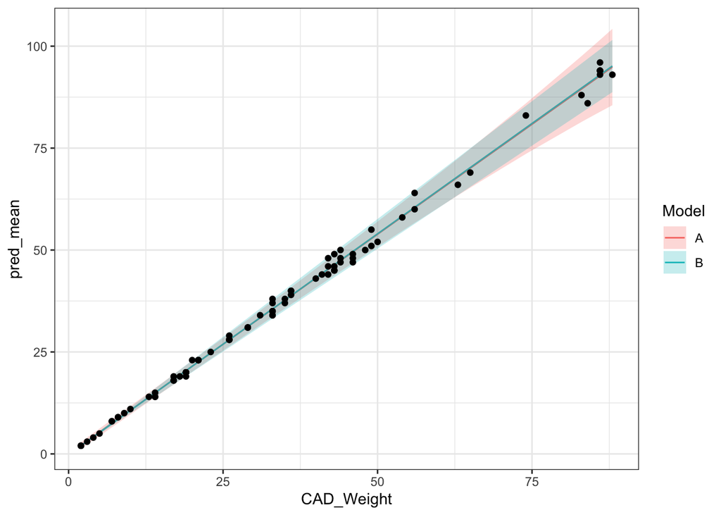

```r
load("filament1.rda")
# Predict using filament1_predict function
est_A <- filament1_estimate(data = filament1, model = "A")
est_B <- filament1_estimate(data = filament1, model = "B")

pred_filament1_A <- filament1_predict(est_A, newdata = filament1, model = "A")
pred_filament1_B <- filament1_predict(est_B, newdata = filament1, model = "B")

ggplot(rbind(cbind(pred_filament1_A, filament1, Model = "A"),cbind(pred_filament1_B, filament1, Model = "B")), mapping=aes(CAD_Weight))+
  geom_line(aes(y=pred_mean, col= Model)) +
  geom_ribbon(aes(ymin=lwr, ymax=upr, fill=Model), alpha=0.25) +
  geom_point(aes(y=Actual_Weight), data = filament1)
```

3. The function leave1out performs leave-one-out cross-validation for the selected model for each observation i = 1, . . . , N . In this function, it first estimates the model parameters using {(xj , yj ), j ̸= i}, computse the prediction information based on xi for prediction model Fi, and then computes the required scores S(Fi,yi).

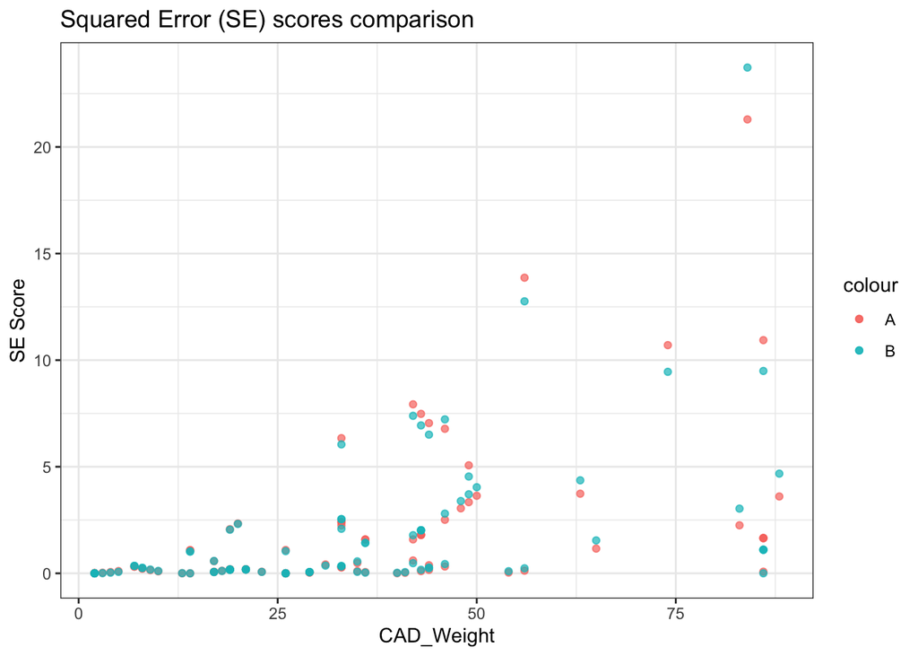

```r
leave1out_A <- leave1out(filament1, "A")
leave1out_B <- leave1out(filament1, "B")

SE_data <- data.frame(CAD_Weight = leave1out_A$CAD_Weight, se_A = leave1out_A$se, se_B = leave1out_B$se)

ggplot() +
  geom_point(aes(CAD_Weight, se_A, colour = "A"), data = SE_data, alpha = 0.7) +
  geom_point(aes(CAD_Weight, se_B, colour = "B"), data = SE_data, alpha = 0.7) +
  labs(title = "Squared Error (SE) scores comparison", x = "CAD_Weight", y = "SE Score")
```

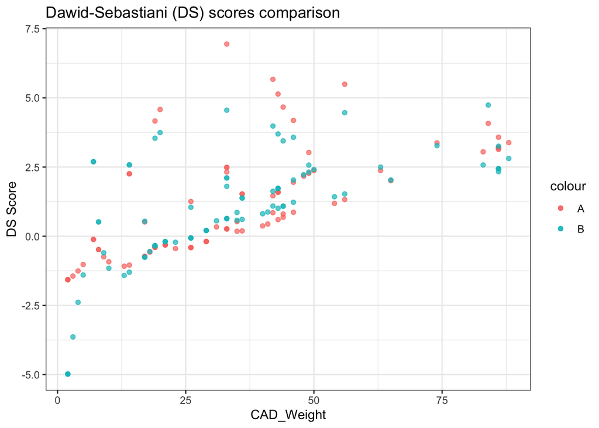

```r
DS_data <- data.frame(CAD_Weight = leave1out_A$CAD_Weight, ds_A = leave1out_A$ds, ds_B = leave1out_B$ds)

ggplot() +
  geom_point(aes(CAD_Weight, ds_A, colour = "A"), data = DS_data, alpha = 0.7) +
  geom_point(aes(CAD_Weight, ds_B, colour = "B"), data = DS_data, alpha = 0.7) +
  labs(title = "Dawid-Sebastiani (DS) scores comparison", x = "CAD_Weight", y = "DS Score")
```

The first graph, which represents the Squared Error scores, indicates that both models perform similarly for smaller CAD_Weights, with lower SE scores suggesting better accuracy. However, as the CAD_Weights increase, the SE scores for the two models diverge more significantly. This implies that the models’ predictions are more accurate for lighter weights compared to heavier ones.

For the Dawid-Sebastiani scores, the plot reveals that the discrepancy between the two models is more pronounced across all CAD_Weights. Specifically, the DS score tends to increase as the CAD_Weights increase. The negative DS scores indicate that the observed data is not fitting the model’s predictions well, possibly, the model is not a good fit for the data.

4. A Monte Carlo estimate of the p-value, testing the exchangeability between model predictions from A and B against the alternative hypothesis that B is better than A, and the Monte Carlo standard errors are presented below.

```r
score_diff <- data.frame(se = SE_data$se_A - SE_data$se_B, ds = DS_data$ds_A - DS_data$ds_B)
statistic0 <- score_diff %>% summarise(se = mean(se), ds = mean(ds))

J <- 10000
statistic <- data.frame(se = numeric(J), ds = numeric(J))

for (loop in seq_len(J)) {
  random_sign <- sample(c(-1, 1), size = nrow(score_diff), replace = TRUE)
  statistic[loop, ] <- score_diff %>% summarise(se = mean(random_sign * se), ds = mean(random_sign * ds))
}

p_values <- statistic %>%
  summarise(se = mean(se > statistic0$se), ds = mean(ds > statistic0$ds))
knitr::kable(p_values, caption = "Monte Carlo estimate of the p-value")
```

Monte Carlo estimate of the p-value

| se | ds |
| --- | --- |
| 0.4989 | 0.0436 |

```r
se_se <- sqrt((p_values$se * (1 - p_values$se)) / J)
se_ds <- sqrt((p_values$ds * (1 - p_values$ds)) / J)

knitr::kable(data.frame(se_se = se_se, se_ds = se_ds), caption = "Monte Carlo standard errors")
```

Monte Carlo standard errors

| se_se | se_ds |
| --- | --- |
| 0.005 | 0.002042 |

A high p-value for the SE score of 0.4989 suggests that the differences in predictions between models A and B are not statistically significant. This indicates that the two models are largely exchangeable with respect to the SE score.

A lower p-value for the DS score of 0.0436 suggests that the differences in predictions between models A and B are statistically significant. This implies that the models are not entirely exchangeable with respect to the DS score.

While the two scores present contrasting results, it might suggest that the observations are not best suited for a DS scoring method.

# 2 Part 2: Archaeology in the Baltic sea

These are the approximate values for the Monte Carlo integration method.

```r
result <- estimate(y = c(237, 256), xi = 1/1001, a = 0.5, b = 0.5, K = 10000)
knitr::kable(result)
```

| p_y | E_N | E_phi |
| --- | --- | --- |
| 7.9e-06 | 981.9492 | 0.3741221 |

The Monte Carlo integration estimated values that make some sense for the priors and the context. The estimate of 982 individuals is fairly close to the 1000 that the archaeologist first thought there would have been.

The estimated phi value of approximately 0.374 suggests that the probability of finding a femur is estimated to be around 37.4% which is much less than the archaeologist expected at 50%.

The very low value of p_y of 0.0000079 indicates that the observed data is quite unlikely under the assumed prior distributions.

The evidence suggests that the actual values of N and phi might differ a lot from the initial assumptions, and therefore a different analysis might be better suited.

# 3 Code appendix

```r
#' Orlagh Keane, s2084384
#' Add your own function definitions on this file.

#' neg_log_lik
#
#' @description Evaluate the negated log-likelihood for model A and B
#' @param beta A vector with the beta parameters
#' @param data A `data.frame` with the same variables as the `filament1` data set.
#' Must have columns `CAD_Weight` and `Actual_Weight`
#' @param model Either "A" for a log-linear variance model, or "B" for a proportional
#' scaling error model

neg_log_lik <- function(beta, data, model){

  mu <- beta[1] + beta[2]*data[["CAD_Weight"]]

  # distinguish between the two models to find the particular standard deviation for the betas
  if(model == "A") {
    sigma <- sqrt(exp(beta[3] + beta[4]*data[["CAD_Weight"]]))
  }else{
    sigma <- sqrt(exp(beta[3])+exp(beta[4]) * (data[["CAD_Weight"]]^2))
  }
  - sum(dnorm(data[["Actual_Weight"]],
              mean = mu,
              sd=sigma,
              log = TRUE))

}

#' filament_estimate
#
#' @description Estimate filament models with different variance structure
#' @param data A `data.frame` with the same variables as the `filament1` data set.
#' Must have columns `CAD_Weight` and `Actual_Weight`
#' @param model Either "A" for a log-linear variance model, or "B" for a proportional
#' scaling error model
#' @return An estimation object suitable for use with [filament1_predict()]

filament1_estimate <- function(data, model) {
  model <- match.arg(model, c("A", "B"))
  if (model == "A") {
    beta_start <- c(-0.1, 1.07, -2, 0.05)
  } else {
    beta_start <- c(-0.15, 1.07, -13.5, -6.5)
  }
  opt <- optim(beta_start,
               neg_log_lik,
               data = data,
               model = model,
               hessian = TRUE,
               method = "Nelder-Mead",
               control = list(maxit = 5000)
  )
  fit <- list(
    model = model,
    par = opt$par,
    hessian = opt$hessian
  )
  class(fit) <- c("filament1_estimate", "list")
  fit
}

#' filament1_aux_EV
#'
#' @description Evaluate the expectation and variance for model A and B
#' @param beta A vector with the beta parameters
#' @param data A `data.frame` containing the required predictors, including `CAD_Weight`
#' @param model Either "A" for a log-linear variance model, or "B" for a proportional
#' scaling error model
#' @param Sigma_beta : If not NULL, an estimate of the covariance matrix for
#                 the uncertainty of estimated betas
#' @return A list with four elements:
#     E : E(y|beta,x)
#     V : Var(y|beta,x)
#     VE : Var(E(y|beta,x)|x) or NULL
#     EV : E(Var(y|beta,x)|x) or NULL

filament1_aux_EV <- function(beta, data, model = c("A", "B"),
                             Sigma_beta = NULL) {

  model <- match.arg(model)
  if (model == "A") {

    ZE.0 <- model.matrix( ~ 1 + CAD_Weight, data = data)
    ZV.0 <- model.matrix( ~ 1 + CAD_Weight, data = data)
    ZE = cbind(ZE.0, ZV.0 * 0)
    ZV = cbind(ZE.0 * 0, ZV.0)

    VE <- EV <- NULL
    if (!is.null(Sigma_beta)) {
      # E(Var(y|beta,x)|x)
      EV <- exp(ZV %*% beta + rowSums(ZV * (ZV %*% Sigma_beta)) / 2)
      # Var(E(y|beta,x)|x)
      VE <- rowSums(ZE * (ZE %*% Sigma_beta))
    }
    out <- list(
      E = ZE %*% beta,
      V = exp(ZV %*% beta),
      VE = VE,
      EV = EV
    )
  } else {

    ZE.0 <- model.matrix( ~ 1 + CAD_Weight, data = data)
    ZV.0 <- model.matrix( ~ 1 + I(CAD_Weight^2), data = data)
    ZE = cbind(ZE.0, ZV.0 * 0)
    ZV = cbind(ZE.0 * 0, ZV.0)

    VE <- EV <- NULL
    if (!is.null(Sigma_beta)) {
      # E(Var(y|beta,x)|x)
      # (pmin: Ignore large Sigma_beta values)
      EV <- ZV %*% exp(beta + pmin(0.5^2, diag(Sigma_beta)) / 2)
      # Var(E(y|beta,x)|x)
      VE <- rowSums(ZE * (ZE %*% Sigma_beta))
    }
    out <- list(
      E = ZE %*% beta,
      V = ZV %*% exp(beta),
      VE = VE,
      EV = EV
    )
  }
  out
}

#' filament1_predict
#'
#' @description Uses estimated model to predict new observations
#' @param est filament1_estimate()
#' @param newdata A `data.frame` to predict
#' @param model Must be A or B
#' @return A data.frame of `pred_mean`, `pred_sd`, `lwr`, and `upr`, from the prediction for each row of `newdata`.
#'
filament1_predict <- function(est, newdata, model=c("A", "B")) {
  theta <- est$par
  Sigma_theta <- solve(est$hessian)
  aux_EV <- filament1_aux_EV(beta = theta, data = newdata, model = model, Sigma_beta = Sigma_theta)
  pred_mean <- aux_EV$E
  pred_var <- aux_EV$V
  pred_sd <- (aux_EV$EV + aux_EV$VE)^0.5
  q <- qt(1 - 0.05 / 2, df = Inf)
  lwr <- pred_mean - q * pred_sd
  upr <- pred_mean + q * pred_sd
  preds <- data.frame(
    pred_mean = pred_mean,
    pred_sd = pred_sd,
    lwr = lwr,
    upr = upr
  )
  return(preds)
}

#' compute_SE
#'
#' @description Compute the Squared Error (SE) score
#' @param actual A numeric vector of actual weights
#' @param predicted_mean A numeric vector of predicted means
#' @return The SE score
#'
compute_SE <- function(actual, predicted_mean) {
  se <- (actual - predicted_mean)^2
  return(se)
}

#' compute_DS
#'
#' @description Compute the Dawid-Sebastiani (DS) score
#' @param actual A numeric vector of actual weights
#' @param predicted_mean A numeric vector of predicted means
#' @param sd A numeric vector of standard deviations
#' @return The DS score
#'
#'
compute_DS <- function(actual, predicted_mean, sd) {
  ds <- ((actual - predicted_mean)^2) / sd^2 + 2 * log(sd)
  return(ds)
}


#' leave1out
#'
#' @description Performs leave-one-out cross-validation for the selected model for each observation
#' @param data A data.frame containing the required predictors
#' @param model Must be A or B
#' @return A data.frame that extends the original data frame with four additional columns mean, sd, se and ds of leave-one-out prediction means
#'
leave1out <- function(data, model=c("A", "B")) {
  data <- data %>% mutate(mean = NA_real_, sd = NA_real_)
  for (i in seq_len(nrow(data))) {
    est <- filament1_estimate(data[-i,], model)
    pred <- filament1_predict(est, newdata = data[i,], model)
    pred_mean <- pred$pred_mean
    pred_sd <- pred$pred_sd
    data[i, "mean"] <- pred_mean
    data[i, "sd"] <- pred_sd
  }
  data <- data %>%
    mutate(
      se = compute_SE(Actual_Weight, mean),
      ds = compute_DS(Actual_Weight, mean, sd)
    )
  data
}

#' arch_loglike
#'
#' @description If a data.frame with columns N and phi is provided, the log-likelihood for each row-pair (N, φ) should be returned.
#' @param data a data.frame with columns N and phi
#' @param y observations
#' @return log-likelihood for each row-pair (N, φ)
#'
arch_loglike <- function(data, y) {
  if (is.data.frame(data) && "N" %in% names(data) && "phi" %in% names(data)) {
    log_like <- rep(-Inf, nrow(data))
    for (i in seq_len(nrow(data))) {
      N <- data$N[i]
      phi <- data$phi[i]
      y1 <- y[1]
      y2 <- y[2]
      log_like[i] <- -lgamma(y1 + 1) - lgamma(y2 + 1) - lgamma(N - y1 + 1) - lgamma(N - y2 + 1) +
          2 * lgamma(N + 1) + (y1 + y2) * log(phi) + (2 * N - y1 - y2) * log(1 - phi)
    }
    return(log_like)
  }
}

#' estimate
#'
#' @description Implements Monte Carlo integration method to approximate py(y), E(N|y), and E(phi|y).
#' @param y numeric vector of observations
#' @param xi probability parameter for geom dist
#' @param a shape1 parameter for beta dist
#' @param b shape2 parameter for beta dist
#' @param K number of Monte Carlo samples
#' @return data.frame of p_y, E_N, and E_phi
#'
estimate <- function(y, xi, a, b, K) {
  N_samples <- rgeom(K, prob = xi)
  phi_samples <- rbeta(K, shape1 = a, shape2 = b)

  log_like <- arch_loglike(data.frame(N = N_samples, phi = phi_samples), y = y)

  p_y <- mean(exp(log_like))
  E_N <- mean(N_samples * exp(log_like) / p_y)
  E_phi <- mean(phi_samples * exp(log_like) / p_y)

  return(data.frame(p_y = p_y, E_N = E_N, E_phi = E_phi))
}
```